# Customer churn analysis

Customer churn, also known as customer attrition, happens when the customer chooses to stop using products or services. In this dataset, churn value indicates whether the customer has discontinued the service during the last month. Being able to predict which customers are most likely to churn can be very beneficial for business.

The analysis procedes in the following sections:

1. Loading and cleaning the dataset
2. Exploratory data analysis
3. Feature engineering
4. Model building

The data used is from Kaggle: https://www.kaggle.com/datasets/blastchar/telco-customer-churn/

## 1. Loading and cleaning the dataset

```python
import warnings
warnings.filterwarnings("ignore", category=FutureWarning)
```

```python
import pandas as pd
import matplotlib.pyplot as plt
import seaborn as sns

# Import data from a csv file into a dataframe
df = pd.read_csv("Telco-Customer-Churn.csv")
df.head()
```

|  | customerID | gender | SeniorCitizen | Partner | Dependents | tenure | PhoneService | MultipleLines | InternetService | OnlineSecurity | ... | DeviceProtection | TechSupport | StreamingTV | StreamingMovies | Contract | PaperlessBilling | PaymentMethod | MonthlyCharges | TotalCharges | Churn |
| --- | --- | --- | --- | --- | --- | --- | --- | --- | --- | --- | --- | --- | --- | --- | --- | --- | --- | --- | --- | --- | --- |
| 0 | 7590-VHVEG | Female | 0 | Yes | No | 1 | No | No phone service | DSL | No | ... | No | No | No | No | Month-to-month | Yes | Electronic check | 29.85 | 29.85 | No |
| 1 | 5575-GNVDE | Male | 0 | No | No | 34 | Yes | No | DSL | Yes | ... | Yes | No | No | No | One year | No | Mailed check | 56.95 | 1889.5 | No |
| 2 | 3668-QPYBK | Male | 0 | No | No | 2 | Yes | No | DSL | Yes | ... | No | No | No | No | Month-to-month | Yes | Mailed check | 53.85 | 108.15 | Yes |
| 3 | 7795-CFOCW | Male | 0 | No | No | 45 | No | No phone service | DSL | Yes | ... | Yes | Yes | No | No | One year | No | Bank transfer (automatic) | 42.30 | 1840.75 | No |
| 4 | 9237-HQITU | Female | 0 | No | No | 2 | Yes | No | Fiber optic | No | ... | No | No | No | No | Month-to-month | Yes | Electronic check | 70.70 | 151.65 | Yes |

5 rows × 21 columns

```python
# Produce a summary of the dataset
df.info()
```

```
<class 'pandas.core.frame.DataFrame'>
RangeIndex: 7043 entries, 0 to 7042
Data columns (total 21 columns):
 #   Column            Non-Null Count  Dtype
---  ------            --------------  -----
 0   customerID        7043 non-null   object
 1   gender            7043 non-null   object
 2   SeniorCitizen     7043 non-null   int64
 3   Partner           7043 non-null   object
 4   Dependents        7043 non-null   object
 5   tenure            7043 non-null   int64
 6   PhoneService      7043 non-null   object
 7   MultipleLines     7043 non-null   object
 8   InternetService   7043 non-null   object
 9   OnlineSecurity    7043 non-null   object
 10  OnlineBackup      7043 non-null   object
 11  DeviceProtection  7043 non-null   object
 12  TechSupport       7043 non-null   object
 13  StreamingTV       7043 non-null   object
 14  StreamingMovies   7043 non-null   object
 15  Contract          7043 non-null   object
 16  PaperlessBilling  7043 non-null   object
 17  PaymentMethod     7043 non-null   object
 18  MonthlyCharges    7043 non-null   float64
 19  TotalCharges      7043 non-null   object
 20  Churn             7043 non-null   object
dtypes: float64(1), int64(2), object(18)
memory usage: 1.1+ MB
```

In the summary, we can see that the data totals 7043 rows, with 21 columns, none of which have null values. There are three columns which have numerical data type, the rest are currently strings (=object).

```python
# Convert Total charges to numeric, any values that cannot be converted are replaced with NaN.
df["TotalCharges"] = pd.to_numeric(df["TotalCharges"], errors="coerce")

# Check for null values
df.isnull().sum()
```

```
customerID           0
gender               0
SeniorCitizen        0
Partner              0
Dependents           0
tenure               0
PhoneService         0
MultipleLines        0
InternetService      0
OnlineSecurity       0
OnlineBackup         0
DeviceProtection     0
TechSupport          0
StreamingTV          0
StreamingMovies      0
Contract             0
PaperlessBilling     0
PaymentMethod        0
MonthlyCharges       0
TotalCharges        11
Churn                0
dtype: int64
```

```python
# Replace the 11 null values with the median for total charges, so as not to skew the results of the analysis
df["TotalCharges"].fillna(df["TotalCharges"].median(), inplace=True)
```

```python
# Basic descriptive statistics for the numerical columns in the data set
df.describe()
```

|  | SeniorCitizen | tenure | MonthlyCharges | TotalCharges |
| --- | --- | --- | --- | --- |
| count | 7043.000000 | 7043.000000 | 7043.000000 | 7043.000000 |
| mean | 0.162147 | 32.371149 | 64.761692 | 2281.916928 |
| std | 0.368612 | 24.559481 | 30.090047 | 2265.270398 |
| min | 0.000000 | 0.000000 | 18.250000 | 18.800000 |
| 25% | 0.000000 | 9.000000 | 35.500000 | 402.225000 |
| 50% | 0.000000 | 29.000000 | 70.350000 | 1397.475000 |
| 75% | 0.000000 | 55.000000 | 89.850000 | 3786.600000 |
| max | 1.000000 | 72.000000 | 118.750000 | 8684.800000 |

```python
print(df.columns)
```

```
Index(['customerID', 'gender', 'SeniorCitizen', 'Partner', 'Dependents',
       'tenure', 'PhoneService', 'MultipleLines', 'InternetService',
       'OnlineSecurity', 'OnlineBackup', 'DeviceProtection', 'TechSupport',
       'StreamingTV', 'StreamingMovies', 'Contract', 'PaperlessBilling',
       'PaymentMethod', 'MonthlyCharges', 'TotalCharges', 'Churn'],
      dtype='object')
```

```python
# Drop unnecessary columns
df.drop(columns=["customerID"], inplace=True)
```

```python
# Check for and drop duplicate rows in the data
df.duplicated().sum()
df.drop_duplicates(inplace=True)
```

```python
df.info()
```

```
<class 'pandas.core.frame.DataFrame'>
Index: 7021 entries, 0 to 7042
Data columns (total 20 columns):
 #   Column            Non-Null Count  Dtype
---  ------            --------------  -----
 0   gender            7021 non-null   object
 1   SeniorCitizen     7021 non-null   int64
 2   Partner           7021 non-null   object
 3   Dependents        7021 non-null   object
 4   tenure            7021 non-null   int64
 5   PhoneService      7021 non-null   object
 6   MultipleLines     7021 non-null   object
 7   InternetService   7021 non-null   object
 8   OnlineSecurity    7021 non-null   object
 9   OnlineBackup      7021 non-null   object
 10  DeviceProtection  7021 non-null   object
 11  TechSupport       7021 non-null   object
 12  StreamingTV       7021 non-null   object
 13  StreamingMovies   7021 non-null   object
 14  Contract          7021 non-null   object
 15  PaperlessBilling  7021 non-null   object
 16  PaymentMethod     7021 non-null   object
 17  MonthlyCharges    7021 non-null   float64
 18  TotalCharges      7021 non-null   float64
 19  Churn             7021 non-null   object
dtypes: float64(2), int64(2), object(16)
memory usage: 1.1+ MB
```

## 2. Exploratory data analysis

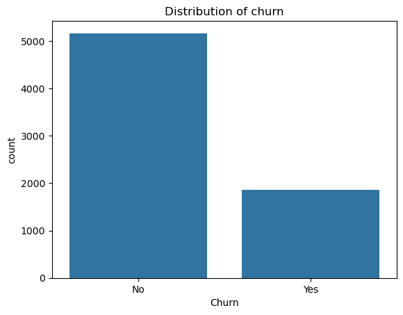

```python
# Visualize the Churn variable. Yes indicates a customer that has left within the last month.
sns.countplot(x="Churn", data=df)
plt.title("Distribution of churn")
plt.show()
```

```python
# Calculate percentage of churn vs. non-churn
churn_rate = df["Churn"].value_counts(normalize=True) * 100
print(churn_rate)
```

```
Churn
No     73.550776
Yes    26.449224
Name: proportion, dtype: float64
```

26,4 % of customers have left within the previous month.

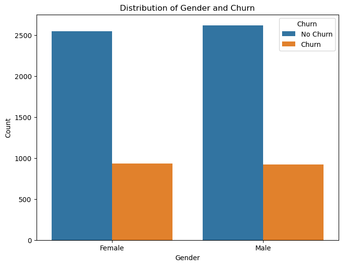

```python
# Grouped bar plot
plt.figure(figsize=(8, 6))
sns.countplot(x='gender', hue='Churn', data=df)
plt.title('Distribution of Gender and Churn')
plt.xlabel('Gender')
plt.ylabel('Count')
plt.legend(title='Churn', loc='upper right', labels=['No Churn', 'Churn'])
plt.show()
```

There is an even distribution of gender in the data and there appears to be no difference in rates of churn between genders.

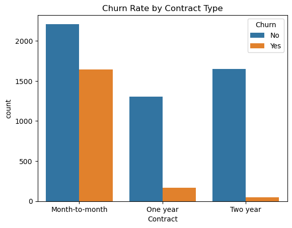

```python
# Visualize the distribution of churn by contract type
sns.countplot(x="Contract", hue="Churn", data=df)
plt.title("Churn Rate by Contract Type")
plt.show()
```

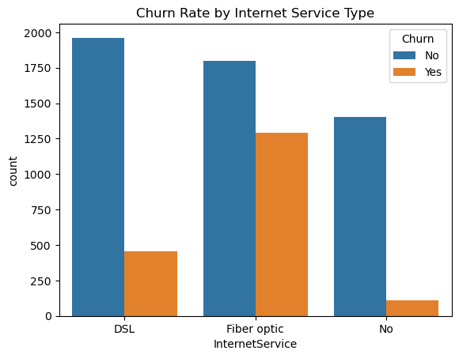

```python
# Visualize distribution of churn by the type of internet service
sns.countplot(x="InternetService", hue="Churn", data=df)
plt.title("Churn Rate by Internet Service Type")
plt.show()
```

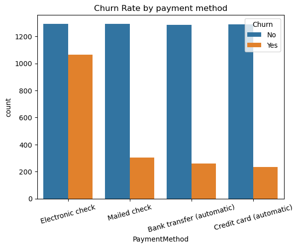

```python
# Visualize distribution of churn by payment method
sns.countplot(x="PaymentMethod", hue="Churn", data=df)
plt.xticks(rotation=15)  # Rotate x-axis labels
plt.title("Churn Rate by payment method")
plt.show()
```

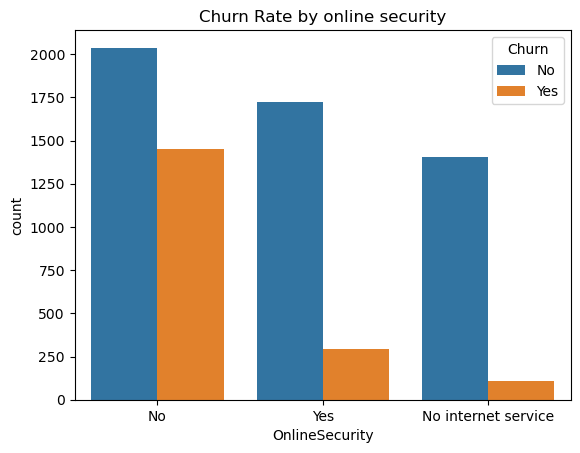

```python
# Visualize distribution of churn by online security
sns.countplot(x="OnlineSecurity", hue="Churn", data=df)
plt.title("Churn Rate by online security")
plt.show()
```

From these plots we can see that there is a difference in churn rates between different contract types, Internet service types, payment methods and online security.

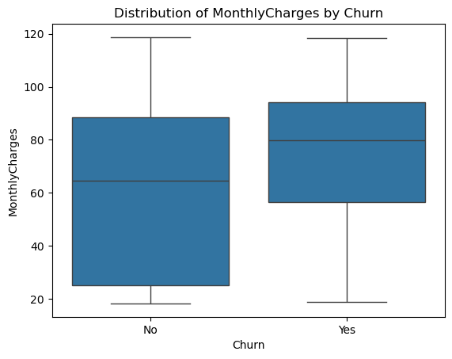

```python
# Boxplot for TotalCharges
sns.boxplot(x="Churn", y="MonthlyCharges", data=df)
plt.title("Distribution of MonthlyCharges by Churn")
plt.show()
```

The median of monthly charges is higher for customers who leave.

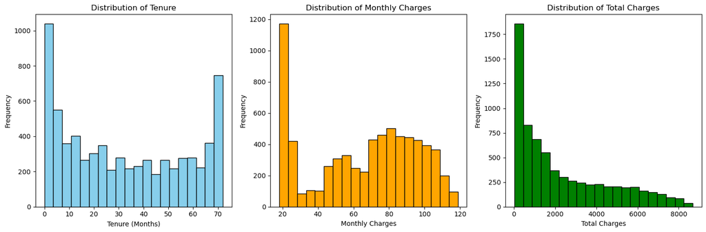

```python
plt.figure(figsize=(15, 5))

# Plot histogram for "tenure"
plt.subplot(1, 3, 1)
plt.hist(df["tenure"], bins=20, color="skyblue", edgecolor="black")
plt.title("Distribution of Tenure")
plt.xlabel("Tenure (Months)")
plt.ylabel("Frequency")

# Plot histogram for "MonthlyCharges"
plt.subplot(1, 3, 2)
plt.hist(df["MonthlyCharges"], bins=20, color="orange", edgecolor="black")
plt.title("Distribution of Monthly Charges")
plt.xlabel("Monthly Charges")
plt.ylabel("Frequency")

# Plot histogram for "TotalCharges"
plt.subplot(1, 3, 3)
plt.hist(df["TotalCharges"], bins=20, color="green", edgecolor="black")
plt.title("Distribution of Total Charges")
plt.xlabel("Total Charges")
plt.ylabel("Frequency")

plt.tight_layout()
plt.show()
```

Tenure

- There is a fairly even distribution of tenures, with peaks at both ends, indicating that there is a significant amount of both very new and very old customers.

Total Charges

- total charges depend on tenure and monthly charges. Because both have a far left peak, total charges also reflects that.

There appear to be no significant outliers in the data.

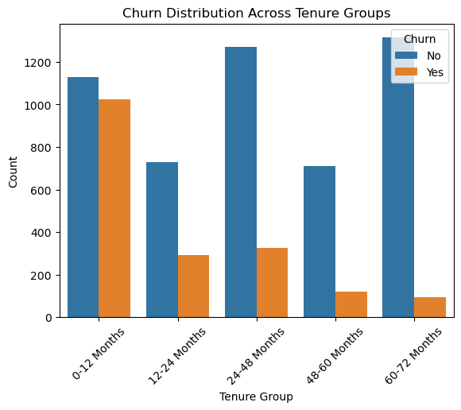

```python
# Create tenure groups and compare them
df["TenureGroup"] = pd.cut(df["tenure"], bins=[0, 12, 24, 48, 60, 72],
                           labels=["0-12 Months", "12-24 Months", "24-48 Months", "48-60 Months", "60-72 Months"])


sns.countplot(x="TenureGroup", hue="Churn", data=df)
plt.title("Churn Distribution Across Tenure Groups")
plt.xlabel("Tenure Group")
plt.ylabel("Count")
plt.xticks(rotation=45)
plt.show()


# Once we"re done with the tenure group analysis, the column is dropped because purely numerical data is needed for further analysis
df.drop(columns=["TenureGroup"], inplace=True)
```

There is a clear difference in churn between the tenure groups. Newer customers are much more likely to abandon the service, while longer-tenured customers are less likely to do so.

Next we will convert the categorical variables in the data set to numerical, in order to enable further analysis and modeling.

```python
# Identify categorical columns
categorical_cols = df.select_dtypes(include=["object"]).columns
print("Categorical columns:", categorical_cols)

# Identify binary columns
binary_columns = [col for col in categorical_cols if df[col].nunique() == 2]
print("Binary columns:", binary_columns)

# Check unique values in binary columns
for col in binary_columns:
    print(f"{col}: {df[col].unique()}")

# Encode binary categorical columns
binary_mapping = {"Yes": 1, "No": 0, "Female": 0, "Male": 1}
for col in binary_columns:
    df[col] = df[col].map(binary_mapping)
```

```
Categorical columns: Index(['gender', 'Partner', 'Dependents', 'PhoneService', 'MultipleLines',
       'InternetService', 'OnlineSecurity', 'OnlineBackup', 'DeviceProtection',
       'TechSupport', 'StreamingTV', 'StreamingMovies', 'Contract',
       'PaperlessBilling', 'PaymentMethod', 'Churn'],
      dtype='object')
Binary columns: ['gender', 'Partner', 'Dependents', 'PhoneService', 'PaperlessBilling', 'Churn']
gender: ['Female' 'Male']
Partner: ['Yes' 'No']
Dependents: ['No' 'Yes']
PhoneService: ['No' 'Yes']
PaperlessBilling: ['Yes' 'No']
Churn: ['No' 'Yes']
```

One-hot encoding is used to convert categorical variables into binary format, so that the data can better be analyzed by machine learning algorithms.

For consistency, all the values are converted to 1 or 0 rather than having a mix of binary and boolean.

```python
# Use one-hot encoding for non-binary categorical variables
non_binary_columns = [col for col in categorical_cols if col not in binary_columns]
print("Non-Binary Categorical Columns:", non_binary_columns)

df = pd.get_dummies(df, columns=non_binary_columns, drop_first=True)

# Convert the column values to binary (1/0) instead of boolean (True/False)
dummy_columns = df.select_dtypes(include=["bool"]).columns
df[dummy_columns] = df[dummy_columns].astype(int)

# Verify changes
df.head()
```

```
Non-Binary Categorical Columns: ['MultipleLines', 'InternetService', 'OnlineSecurity', 'OnlineBackup', 'DeviceProtection', 'TechSupport', 'StreamingTV', 'StreamingMovies', 'Contract', 'PaymentMethod']
```

|  | gender | SeniorCitizen | Partner | Dependents | tenure | PhoneService | PaperlessBilling | MonthlyCharges | TotalCharges | Churn | ... | TechSupport_Yes | StreamingTV_No internet service | StreamingTV_Yes | StreamingMovies_No internet service | StreamingMovies_Yes | Contract_One year | Contract_Two year | PaymentMethod_Credit card (automatic) | PaymentMethod_Electronic check | PaymentMethod_Mailed check |
| --- | --- | --- | --- | --- | --- | --- | --- | --- | --- | --- | --- | --- | --- | --- | --- | --- | --- | --- | --- | --- | --- |
| 0 | 0 | 0 | 1 | 0 | 1 | 0 | 1 | 29.85 | 29.85 | 0 | ... | 0 | 0 | 0 | 0 | 0 | 0 | 0 | 0 | 1 | 0 |
| 1 | 1 | 0 | 0 | 0 | 34 | 1 | 0 | 56.95 | 1889.50 | 0 | ... | 0 | 0 | 0 | 0 | 0 | 1 | 0 | 0 | 0 | 1 |
| 2 | 1 | 0 | 0 | 0 | 2 | 1 | 1 | 53.85 | 108.15 | 1 | ... | 0 | 0 | 0 | 0 | 0 | 0 | 0 | 0 | 0 | 1 |
| 3 | 1 | 0 | 0 | 0 | 45 | 0 | 0 | 42.30 | 1840.75 | 0 | ... | 1 | 0 | 0 | 0 | 0 | 1 | 0 | 0 | 0 | 0 |
| 4 | 0 | 0 | 0 | 0 | 2 | 1 | 1 | 70.70 | 151.65 | 1 | ... | 0 | 0 | 0 | 0 | 0 | 0 | 0 | 0 | 1 | 0 |

5 rows × 31 columns

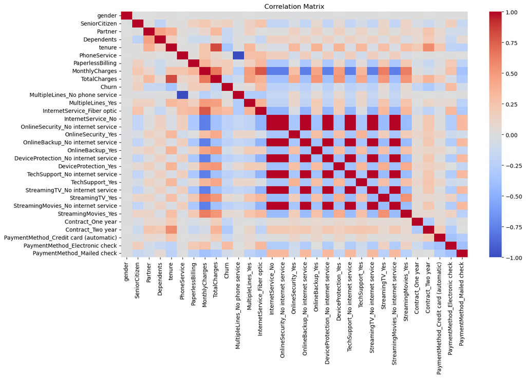

```python
# Compute and visualize a correlation matrix
plt.figure(figsize=(14, 8))
corr_matrix = df.corr()
sns.heatmap(corr_matrix, cmap="coolwarm")
plt.title("Correlation Matrix")
plt.show()
```

### Some notes on how to interpret the correlation matrix.

Positive vs Negative Correlation:

- A positive correlation (close to 1) means two variables move in the same direction.
- A negative correlation (close to -1) means two variables move in opposite directions.

Strength of Correlation:

- Strong correlation: Coefficients close to 1 or -1 (e.g., > 0.8 or < -0.8).
- Moderate correlation: Coefficients between 0.5 and 0.8 (or -0.5 and -0.8).
- Weak correlation: Coefficients between 0 and 0.5.

Limitations:

- Correlation does not imply causation: A strong correlation does not mean one variable causes changes in the other.
- Linear relationship only: The correlation coefficient measures only linear relationships. Non-linear patterns require different analysis techniques.

```python
# Based on the correlation matrix, we can have a closer look at some correlations

correlation1 = df["tenure"].corr(df["TotalCharges"])
correlation2 = df["MonthlyCharges"].corr(df["Churn"])
correlation3 = df["tenure"].corr(df["Churn"])

print(f"The correlation between tenure and total charges is {correlation1:.2f}")
print(f"The correlation between churn and monthly charges is {correlation2:.2f}")
print(f"The correlation between tenure and churn is {correlation3:.2f}")
```

```
The correlation between tenure and total charges is 0.82
The correlation between churn and monthly charges is 0.19
The correlation between tenure and churn is -0.35
```

From these correlations we can see that there is a strong positive correlation between tenure and total charges. Long-standing customers tend to have higher total charges.

The correlation between churn and monthly charge is very weak, from which we can argue that monthly charges may have little to no impact on churn.

There is a weak negative correlation between tenure and churn, which indicates that longer-tenured customers may be less likely to abandon the service.

## 3. Feature engineering

This process transforms the data to enhance predictive modeling.

First we will be scaling to ensure that all numeric columns are on a similar scale. This prevents features with large ranges from dominating the model.

Two new features are created:

- ChargesPerMonth, reflects the mean value the customer has paid per month during their entire tenure and as such aims at capturing historical billing patterns.
- MonthlyContractInteraction, to reflects the combined effect of contract type and monthly charges on customer behavior. For instance, customers paying high monthly charges on a long-term contract may have different churn behavior from those with short-term contracts. Additionally, contract type might have a different importance depending on how much customers are paying monthly.

Finally, multiple columns indicating the same thing, no internet connection, are condensed to just one column.

```python
from sklearn.preprocessing import MinMaxScaler

# Select continuous features for scaling
scaler = MinMaxScaler()
scaled_columns = ["tenure", "MonthlyCharges", "TotalCharges"]
df[scaled_columns] = scaler.fit_transform(df[scaled_columns])
```

```python
# Create TotalCharges per Month feature
df["ChargesPerMonth"] = df["TotalCharges"] / (df["tenure"] + 1e-5)  # Avoid division by zero
```

```python
# Interaction between MonthlyCharges and Contract
df["MonthlyContractInteraction"] = df["MonthlyCharges"] * df["Contract_Two year"]
```

```python
df.head()
```

|  | gender | SeniorCitizen | Partner | Dependents | tenure | PhoneService | PaperlessBilling | MonthlyCharges | TotalCharges | Churn | ... | StreamingTV_Yes | StreamingMovies_No internet service | StreamingMovies_Yes | Contract_One year | Contract_Two year | PaymentMethod_Credit card (automatic) | PaymentMethod_Electronic check | PaymentMethod_Mailed check | ChargesPerMonth | MonthlyContractInteraction |
| --- | --- | --- | --- | --- | --- | --- | --- | --- | --- | --- | --- | --- | --- | --- | --- | --- | --- | --- | --- | --- | --- |
| 0 | 0 | 0 | 1 | 0 | 0.013889 | 0 | 1 | 0.115423 | 0.001275 | 0 | ... | 0 | 0 | 0 | 0 | 0 | 0 | 1 | 0 | 0.091741 | 0.0 |
| 1 | 1 | 0 | 0 | 0 | 0.472222 | 1 | 0 | 0.385075 | 0.215867 | 0 | ... | 0 | 0 | 0 | 1 | 0 | 0 | 0 | 1 | 0.457120 | 0.0 |
| 2 | 1 | 0 | 0 | 0 | 0.027778 | 1 | 1 | 0.354229 | 0.010310 | 1 | ... | 0 | 0 | 0 | 0 | 0 | 0 | 0 | 1 | 0.371041 | 0.0 |
| 3 | 1 | 0 | 0 | 0 | 0.625000 | 0 | 0 | 0.239303 | 0.210241 | 0 | ... | 0 | 0 | 0 | 1 | 0 | 0 | 0 | 0 | 0.336380 | 0.0 |
| 4 | 0 | 0 | 0 | 0 | 0.027778 | 1 | 1 | 0.521891 | 0.015330 | 1 | ... | 0 | 0 | 0 | 0 | 0 | 0 | 1 | 0 | 0.551682 | 0.0 |

5 rows × 33 columns

```python
# Check correlation with Churn again
numeric_df = df.select_dtypes(include=["number"])
correlation_with_churn = numeric_df.corr()["Churn"].sort_values(ascending=False)
print(correlation_with_churn)
```

```
Churn                                    1.000000
InternetService_Fiber optic              0.308170
PaymentMethod_Electronic check           0.301544
MonthlyCharges                           0.194508
PaperlessBilling                         0.190891
SeniorCitizen                            0.151619
StreamingTV_Yes                          0.065032
StreamingMovies_Yes                      0.063192
MultipleLines_Yes                        0.041958
PhoneService                             0.011323
gender                                  -0.008763
MultipleLines_No phone service          -0.011323
ChargesPerMonth                         -0.023700
DeviceProtection_Yes                    -0.064944
OnlineBackup_Yes                        -0.081092
PaymentMethod_Mailed check              -0.092562
PaymentMethod_Credit card (automatic)   -0.133666
Partner                                 -0.149135
Dependents                              -0.163459
TechSupport_Yes                         -0.163937
OnlineSecurity_Yes                      -0.170520
Contract_One year                       -0.177336
TotalCharges                            -0.197911
MonthlyContractInteraction              -0.204353
StreamingMovies_No internet service     -0.228533
StreamingTV_No internet service         -0.228533
TechSupport_No internet service         -0.228533
DeviceProtection_No internet service    -0.228533
OnlineSecurity_No internet service      -0.228533
InternetService_No                      -0.228533
OnlineBackup_No internet service        -0.228533
Contract_Two year                       -0.302076
tenure                                  -0.351508
Name: Churn, dtype: float64
```

There are multiple columns that indicate the same thing: that the customer doesn"t have internet service. These will be condensed to just one column.

```python
# Create a new column "NoInternetService" that is 1 if any of the relevant columns indicate no internet service, otherwise 0
df["NoInternetService"] = df[["StreamingMovies_No internet service",
                              "StreamingTV_No internet service",
                              "TechSupport_No internet service",
                              "DeviceProtection_No internet service",
                              "OnlineSecurity_No internet service",
                              "InternetService_No",
                              "OnlineBackup_No internet service"]].max(axis=1)

# Drop the original columns after combining
columns_to_drop = [
    "StreamingMovies_No internet service",
    "StreamingTV_No internet service",
    "TechSupport_No internet service",
    "DeviceProtection_No internet service",
    "OnlineSecurity_No internet service",
    "InternetService_No",
    "OnlineBackup_No internet service"
]
df.drop(columns=columns_to_drop, inplace=True)
```

```python
# Save the processed data
df.to_csv("processed_telco_churn.csv", index=False)
```

## 4. Model building

```python
# Separate features and target, this prepares the data for modeling
X = df.drop("Churn", axis=1)
y = df["Churn"]
```

```python
# Split the data into training and testing sets

from sklearn.model_selection import train_test_split

X_train, X_test, y_train, y_test = train_test_split(X, y, test_size=0.3, random_state=42)
```

### The models

Three different models were chosen for this project, to represent a variety of different approaches.

Logistic Regression

- Estimates the probability of an outcome (e.g., churn) using a logistic function and a linear combination of input features.
- Assumes a linear relationship between the features and the log-odds of the target variable. It is best for data where this assumption holds true.

Random Forest

- A non-parametric ensemble method that builds multiple decision trees and aggregates their predictions, reducing overfitting and providing feature importance.
- Balances complexity with performance, often excelling in real-world classification tasks by handling non-linearity and noisy data.

Support Vector Machine (SVM)

- A kernel-based classifier that can handle complex, non-linear relationships by finding a hyperplane that maximizes class separation.
- Powerful for high-dimensional data and non-linear problems, making it a good choice when relationships are complex.

```python
# try different models to find the one that performs best with the data

# 1. Logistic regression
from sklearn.linear_model import LogisticRegression

lr_model = LogisticRegression(max_iter=1000)
lr_model.fit(X_train, y_train)


# 2. Random forest classifier
from sklearn.ensemble import RandomForestClassifier

rf_model = RandomForestClassifier(n_estimators=100, random_state=42)
rf_model.fit(X_train, y_train)


# 3. Support Vector Machine (SVM)

from sklearn.svm import SVC

svm_model = SVC(kernel="linear", probability=True)
svm_model.fit(X_train, y_train)
```

```
SVC(kernel='linear', probability=True)
```

Next we will examine the accuracy of the three models using a classification report, accuracy score and a confusion matrix

```python
from sklearn.metrics import classification_report, accuracy_score

# Logistic regression
y_pred1 = lr_model.predict(X_test)
print("Logistic Regression:")
print(classification_report(y_test, y_pred1))
print("Accuracy:", accuracy_score(y_test, y_pred1))
```

```
Logistic Regression:
              precision    recall  f1-score   support

           0       0.85      0.89      0.87      1556
           1       0.64      0.54      0.59       551

    accuracy                           0.80      2107
   macro avg       0.74      0.72      0.73      2107
weighted avg       0.79      0.80      0.80      2107

Accuracy: 0.8011390602752729
```

```python
# Random forest classifier

y_pred2 = rf_model.predict(X_test)
print("Random forest classifier:")
print(classification_report(y_test, y_pred2))
print("Accuracy:", accuracy_score(y_test, y_pred2))
```

```
Random forest classifier:
              precision    recall  f1-score   support

           0       0.83      0.89      0.86      1556
           1       0.62      0.49      0.55       551

    accuracy                           0.79      2107
   macro avg       0.73      0.69      0.71      2107
weighted avg       0.78      0.79      0.78      2107

Accuracy: 0.7883246321784527
```

```python
# Support Vector Machine (SVM)

y_pred3 = svm_model.predict(X_test)
print("Support Vector Machine:")
print(classification_report(y_test, y_pred3))
print("Accuracy:", accuracy_score(y_test, y_pred3))
```

```
Support Vector Machine:
              precision    recall  f1-score   support

           0       0.84      0.90      0.87      1556
           1       0.64      0.53      0.58       551

    accuracy                           0.80      2107
   macro avg       0.74      0.71      0.73      2107
weighted avg       0.79      0.80      0.79      2107

Accuracy: 0.8011390602752729
```

The classification reports for each model show that there are only small differences in precision, recall and overall accuracy.

A confusion matrix is another way to examine the performance of a model. The matrix visualizes the results in four categories:

- True negatives: cases where the model correctly predicted the negative class (upper-left in the matrix)
- False negatives: cases where the model incorrectly predicted negative, when it should have been positive (lower-left)
- False positives: cases where the model incorrectly predicted the positive class, when it should have been negative (upper-right)
- True positives: cases where the model correctly predicted positive class (lower-right)

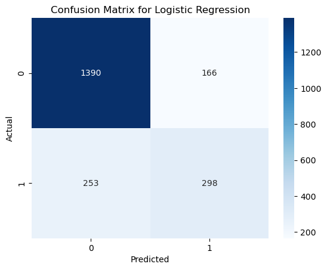

```python
from sklearn.metrics import confusion_matrix

# Confusion matrix for logistic regression
cm1 = confusion_matrix(y_test, y_pred1)
sns.heatmap(cm1, annot=True, fmt="d", cmap="Blues")
plt.xlabel("Predicted")
plt.ylabel("Actual")
plt.title("Confusion Matrix for Logistic Regression")
plt.show()
```

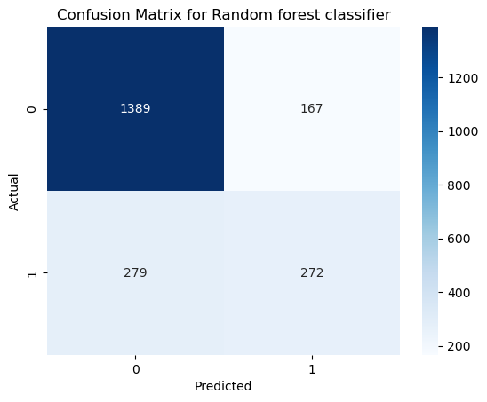

```python
# Confusion matrix for ranfom forest classifier

cm2 = confusion_matrix(y_test, y_pred2)
sns.heatmap(cm2, annot=True, fmt="d", cmap="Blues")
plt.xlabel("Predicted")
plt.ylabel("Actual")
plt.title("Confusion Matrix for Random forest classifier")
plt.show()
```

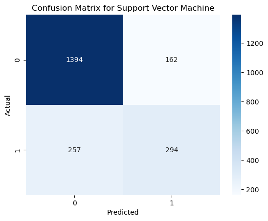

```python
# Confusion matrix Support Vector Machine

cm3 = confusion_matrix(y_test, y_pred3)
sns.heatmap(cm3, annot=True, fmt="d", cmap="Blues")
plt.xlabel("Predicted")
plt.ylabel("Actual")
plt.title("Confusion Matrix for Support Vector Machine")
plt.show()
```

Both the confusion matrices and the accuracy reports show that all models were had more problems with false negatives than with false positives.

```python
# Cross-validation is used to examine whether the model generalizes well

from sklearn.model_selection import cross_val_score

cv_scores1 = cross_val_score(lr_model, X_train, y_train, cv=5)
print(f"Logistic Regression Cross-Validation Scores: {cv_scores1}")
print(f"Mean CV Accuracy: {cv_scores1.mean()}")
print("")
cv_scores2 = cross_val_score(rf_model, X_train, y_train, cv=5)
print(f"Random forest feature Cross-Validation Scores: {cv_scores2}")
print(f"Mean CV Accuracy: {cv_scores2.mean()}")
print("")
cv_scores3 = cross_val_score(svm_model, X_train, y_train, cv=5)
print(f"Support Vector Machine Cross-Validation Scores: {cv_scores3}")
print(f"Mean CV Accuracy: {cv_scores3.mean()}")
```

```
Logistic Regression Cross-Validation Scores: [0.8138352  0.81892167 0.78942014 0.80061038 0.80040733]
Mean CV Accuracy: 0.804638943505997

Random forest feature Cross-Validation Scores: [0.79755849 0.80366226 0.79755849 0.78433367 0.79124236]
Mean CV Accuracy: 0.7948710564318465

Support Vector Machine Cross-Validation Scores: [0.80366226 0.81485249 0.78840285 0.80366226 0.80040733]
Mean CV Accuracy: 0.8021974379108799
```

Cross-validation is used to assess how well a machine learning model will perform on unseen data. It helps evaluate the model’s ability to generalize by splitting the dataset into multiple subsets and training/testing on different combinations of these subsets.

From these results we can see that all three models are performing well, with a very slight advantage to logistic regression.

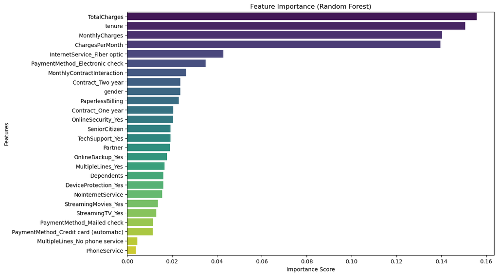

```python
# Examine the most important features, according to the random forest feature model

# Get feature importance from Random Forest
importances = pd.Series(rf_model.feature_importances_, index=X_train.columns)
# Sort by importance
importances = importances.sort_values(ascending=False)

# Plot
plt.figure(figsize=(12, 8))
sns.barplot(x=importances, y=importances.index, palette="viridis")
plt.title("Feature Importance (Random Forest)")
plt.xlabel("Importance Score")
plt.ylabel("Features")
plt.show()
```

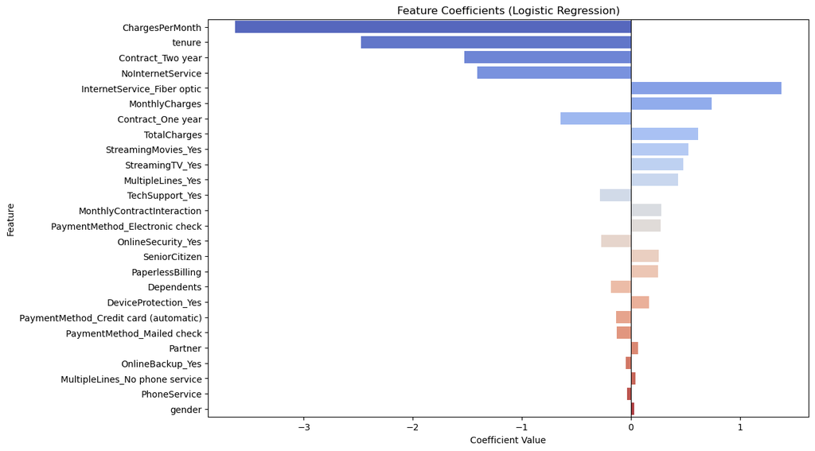

```python
# Examine the most important features according to the logistic regression model

importance = lr_model.coef_[0]
features = df.drop('Churn', axis=1).columns

# Create a DataFrame for visualization
coef_df = pd.DataFrame({'Feature': features, 'Coefficient': importance})

# Sort by the absolute value of the coefficients to show the most influential features first
coef_df['AbsoluteCoefficient'] = coef_df['Coefficient'].abs()
coef_df = coef_df.sort_values(by='AbsoluteCoefficient', ascending=False)

# Plot
plt.figure(figsize=(12, 8))
sns.barplot(x='Coefficient', y='Feature', data=coef_df, palette='coolwarm', orient='h')
plt.title('Feature Coefficients (Logistic Regression)')
plt.xlabel('Coefficient Value')
plt.ylabel('Feature')
plt.axvline(0, color='black', linewidth=0.8)  # Line to separate positive/negative influence
plt.show()
```

It should be noted that the two models have different lists of most important features because they work differently: The logistic regression model assumes a linear relationship between the features and the target, while random forest is a non-linear model that captures complex interactions between features.

Overall, both models consider ChargesPerMonth, Tenure, MonthlyCharges and InternetService_Fiber_optic important, so these features likely have a strong effect.

For further evaluation of the predictive power of the logistic regression model, we can plot a ROC (Receiver Operating Characteristic) curve to show the trade-off between the true positive rate and false positive rate for different thresholds.

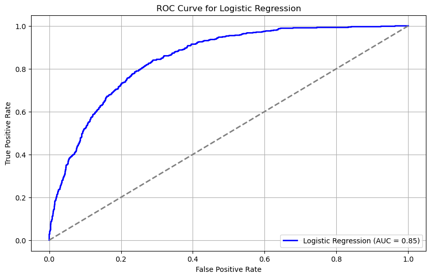

```python
# ROC curve for the logistic regression model

from sklearn.metrics import roc_curve, auc
import matplotlib.pyplot as plt

y_pred_proba = lr_model.predict_proba(X_test)[:, 1]  # Probability estimates for the positive class (Churn = 1)
fpr, tpr, thresholds = roc_curve(y_test, y_pred_proba)
roc_auc = auc(fpr, tpr)  # Area Under the Curve

# Plot the ROC curve
plt.figure(figsize=(10, 6))
plt.plot(fpr, tpr, color="blue", lw=2, label=f"Logistic Regression (AUC = {roc_auc:.2f})")
plt.plot([0, 1], [0, 1], linestyle="--", color="gray", lw=2)  # Diagonal reference line
plt.xlabel("False Positive Rate")
plt.ylabel("True Positive Rate")
plt.title("ROC Curve for Logistic Regression")
plt.legend(loc="lower right")
plt.grid(True)
plt.show()
```

The ROC shows on the x-axis the false positive rate, and on the y-axis the true positive rate. The higher the AUC (area under curve), the better the prediction power of the model. The gray diagonal line indicates a random classifier with no predictive power. The logistic regression model has an AUC score of 0.85, making it a strong model.